# Reproducible Research: Peer Assessment 1

## Loading and preprocessing the data

```r
# Firstly, load required libraries
library(dplyr)
library(lubridate)
library(lattice)

# Check whether the CSV file exists and, if not, extract it from zip file
if( !file.exists("./activity.csv") ){
    unzip("./activity.zip")
}

# Load it into R
d <- read.csv("activity.csv", colClasses = c("integer", "Date", "integer"))

# Function for consistent printing of numbers
specify_decimal <- function(x, k=3){
    format(round(x, k), nsmall=k)
}

# Function that verifies whether a day is weekday (0) or weekend (1)
isWeekday <- function(d){
   if(wday(d) > 1 && wday(d) < 7){
       0
   }else{
       1
   }
}
```

## What is mean total number of steps taken per day?

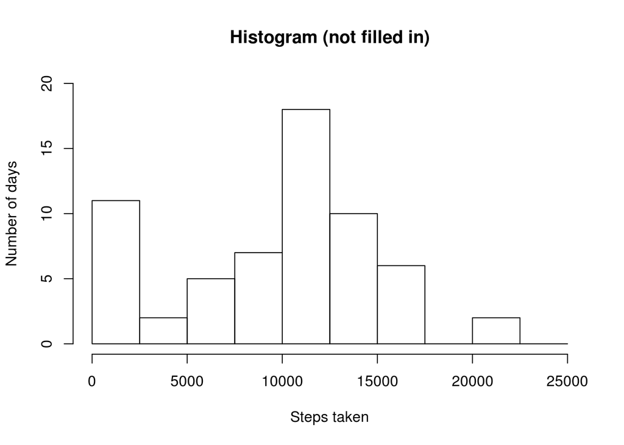

```r
# Calculate some daily stats of the steps taken
daily_stats <- group_by(d, date) %>%
               summarise(total=sum(steps, na.rm = TRUE),
                         mean=mean(steps, na.rm = TRUE)
)

# Generate and plot a histogram of the total number of steps taken
hist(daily_stats$total,
     breaks = seq(0, 25000, length.out = 11),
     ylim = c(0, 20),
     main = "Histogram (not filled in)",
     xlab = "Steps taken",
     ylab = "Number of days"
)
```

```r
# The mean of the total number os steps taken per day
d_mean <- mean(daily_stats$total, na.rm = TRUE)

# The median of the total number os steps taken per day
d_median <- median(daily_stats$total, na.rm = TRUE)
```

Above we can see the histogram of the numbers of days by the total numbers of steps taken.  
The main observations are:

- There are **18** days with total number of steps between **10000** and **12500** steps
- The average number of total steps taken is **9354.230**
- The median number of total steps taken is **10395.000**

## What is the average daily activity pattern?

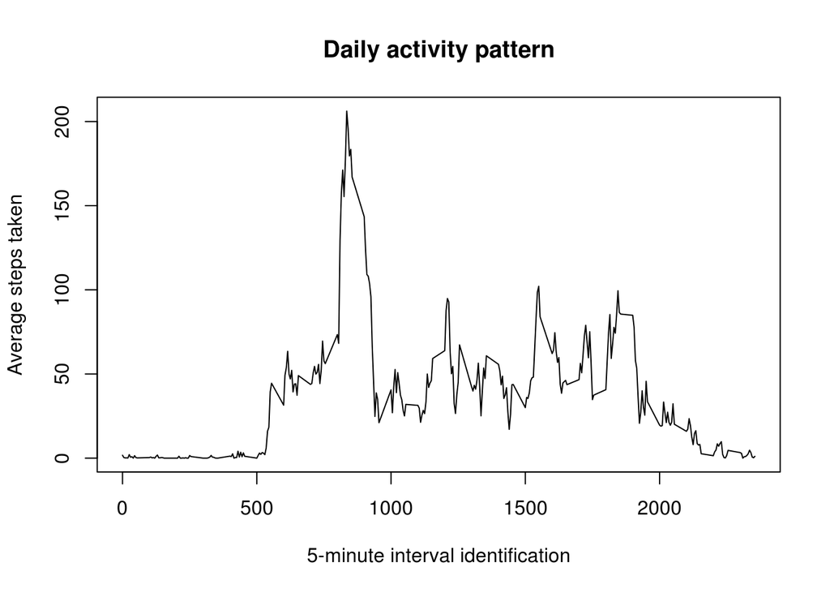

```r
# Firstly, we average the 5-minute interval across all days
interval_stats <- group_by(d, interval) %>%
                  summarise(total=sum(steps, na.rm = TRUE),
                            mean=mean(steps, na.rm = TRUE)
)

# Then we plot
with(interval_stats,
     plot(interval, mean, type = "l",
          main = "Daily activity pattern",
          xlab = "5-minute interval identification",
          ylab = "Average steps taken"
     )
)
```

```r
# The 5-minute interval that contais the maximum number of steps
maxInterval <- interval_stats$interval[which.max(interval_stats$mean)]
```

The time series above shows the daily activity pattern of the measure data. Main observations:

- Most activity happens between the **500** and **2000** intervals.
- The interval **835** contains the maximum average number of steps taken.

## Inputing missing values

```r
# Calculate and report the total number of missing values in the dataset

# The number of NA's values are
d_na <- sum(is.na(d$steps))

# Create a new dataset that is equal to the original dataset
# but with the missing data filled in.

# Copy the dataset to a new object
d_filled <- d

# Lets replace the NA's by the interval average across all days

# Get the vector of 'interval' with missing 'steps'
intervals.na <- d_filled$interval[is.na(d_filled$steps)]

# Create a function that searchs for interval indexes
# on 'where' that are equal to 'x'
findIntervalIndexes <- function(x, where = interval_stats){
    which(where$interval == x)
}

# Get corresponding indexes of 'interval' in 'interval_stats'
indexes <- sapply(intervals.na, findIntervalIndexes)

# Replace NA values with corresponding values from 'interval_stats'
d_filled$steps[is.na(d_filled$steps)] <- interval_stats$mean[indexes]

# Confirming we don't have NA's values anymore
d_filled_na <- sum(is.na(d_filled$steps))
```

We can see that the original data set has **2304** missing entries.  
After filling in the missing values with the respective interval average, there are **0** missing entries remaining.

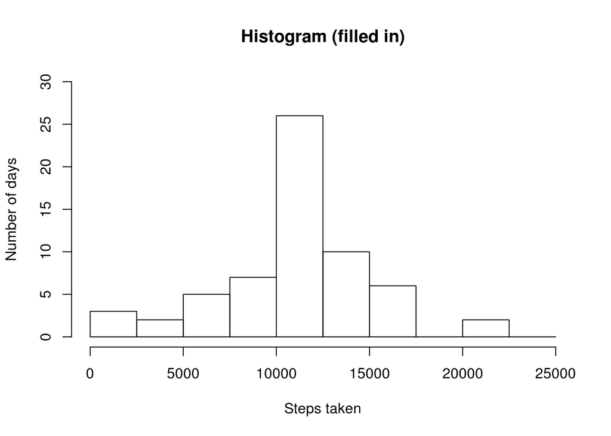

```r
# Calculate the mean and median total number of steps taken per day.
daily_filled_stats <- group_by(d_filled, date) %>%
                      summarise(total=sum(steps, na.rm = FALSE),
                                mean=mean(steps, na.rm = FALSE)
)

# Generate and plot a histogram of the total number of steps taken
hist(daily_filled_stats$total,
     breaks = seq(0, 25000, length.out = 11),
     ylim = c(0, 30),
     main = "Histogram (filled in)",
     xlab = "Steps taken",
     ylab = "Number of days"
)
```

```r
# The mean of the total number os steps taken per day
d_filled_mean <- mean(daily_filled_stats$total, na.rm = FALSE)

# The median of the total number os steps taken per day
d_filled_median <- median(daily_filled_stats$total, na.rm = FALSE)
```

Above we can see the histogram of the numbers of days by the total numbers of steps taken. The main observations are:

- Now there are **26** days with total number of steps between **10000** and **12500** steps.
- The number of days with **0 to 2500** steps dropped from **11** to **3**.
- The average number of total steps taken now is **10766.189**.
- The median number of total steps taken now is **10766.189**.

## Are there differences in activity patterns between weekdays and weekends?

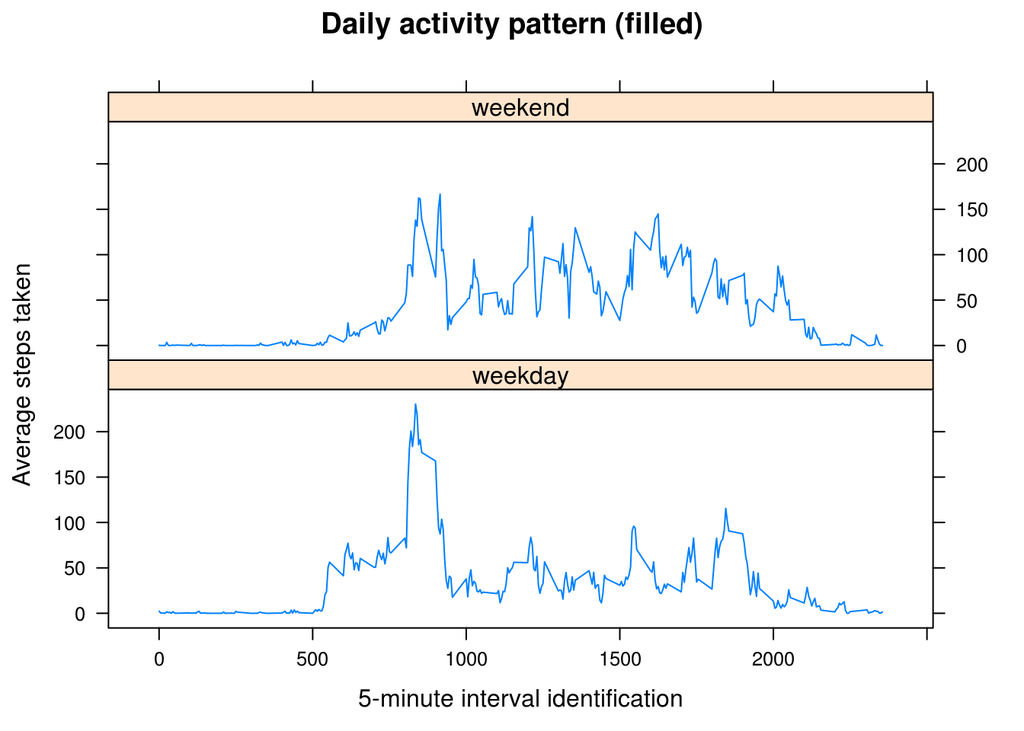

```r
# Create a new factor variable in the dataset with two levels
# “weekday” and “weekend”

# Fill the new factor variable with respective values
d_filled$wd   <- factor(sapply(d_filled$date, isWeekday),
                        levels = c(0, 1),
                        labels = c("weekday", "weekend")
)

# We average the 5-minute interval
interval_filled_stats <- group_by(d_filled, wd, interval) %>%
                         summarise(total=sum(steps, na.rm = FALSE),
                                   mean=mean(steps, na.rm = FALSE)
                         )

# Make a panel plot containing a time series plot
xyplot(mean ~ interval|wd,
       data = interval_filled_stats,
       type = "l",
       layout=c(1,2),
       main = "Daily activity pattern (filled)",
       xlab = "5-minute interval identification",
       ylab = "Average steps taken"
)
```